# Breast_Cancer_code_05

## Breast_cancer analysis

### Step 0 : usage library

설치 안된 라이브러리의 경우 설치 필요

```r
library(tidyverse)
library(caret)
library(ggfortify)
library(randomForest)
```

이것은 또 다른 분류 예입니다. 유방 종양을 악성 또는 양성으로 분류해야 합니다.

우리는 아래 참조 섹션에 나열된 여러 블로그에서 아이디어를 얻었습니다.

### Step 1 : Import the data

```r
library(tidyverse)
df <- read.csv("./data/breast_cancer.csv")

# NULL Data인 X열 제외
df <- df %>% select(-X)

# 이것은 가장 중요한 단계:
# 각 변수에 적절한 클래스가 있는지 확인
str(df)
```

```
## 'data.frame':    569 obs. of  32 variables:
##  $ id                     : int  842302 842517 84300903 84348301 84358402 843786 844359 84458202 844981 84501001 ...
##  $ diagnosis              : chr  "M" "M" "M" "M" ...
##  $ radius_mean            : num  18 20.6 19.7 11.4 20.3 ...
##  $ texture_mean           : num  10.4 17.8 21.2 20.4 14.3 ...
##  $ perimeter_mean         : num  122.8 132.9 130 77.6 135.1 ...
##  $ area_mean              : num  1001 1326 1203 386 1297 ...
##  $ smoothness_mean        : num  0.1184 0.0847 0.1096 0.1425 0.1003 ...
##  $ compactness_mean       : num  0.2776 0.0786 0.1599 0.2839 0.1328 ...
##  $ concavity_mean         : num  0.3001 0.0869 0.1974 0.2414 0.198 ...
##  $ concave.points_mean    : num  0.1471 0.0702 0.1279 0.1052 0.1043 ...
##  $ symmetry_mean          : num  0.242 0.181 0.207 0.26 0.181 ...
##  $ fractal_dimension_mean : num  0.0787 0.0567 0.06 0.0974 0.0588 ...
##  $ radius_se              : num  1.095 0.543 0.746 0.496 0.757 ...
##  $ texture_se             : num  0.905 0.734 0.787 1.156 0.781 ...
```

[output cut: 18 more lines]

그래서 우리는 32 변수를 가진 569 관측치를 갖게 되었습니다. 이상적으로는 변수가 너무 많으면 몇 가지 더 많은 관찰을 얻는 것이 적절할 것입니다.

또한 수치 변수의 값 범위를 확인할 수 있습니다. 분명히, 기계 학습 알고리즘을 실행하기 전에 데이터를 정규화해야 합니다.

### Step 2 : Tidy the data(데이터를 정리)

결과 변수에 대한 변수 유형의 기본 변경 및 잘못 인코딩된 변수의 이름 변경

```r
df$diagnosis <- as.factor(df$diagnosis)
```

데이터 세트를 실행 가능하게 만들기 위해 정리할 작업이 거의 없다는 것은 매우 이례적입니다. 그대로 진행

### Step 3 : Understand the data

이것이 데이터 처리의 순환 단계입니다. 여기에서 각각의 변형, 시각화 및 모델링 단계가 서로 강화되어 더 나은 이해를 이끌어냅니다.

Check for missing values

```r
map_int(df, function(.x) sum(is.na(.x)))
```

```
##                      id               diagnosis             radius_mean
##                       0                       0                       0
##            texture_mean          perimeter_mean               area_mean
##                       0                       0                       0
##         smoothness_mean        compactness_mean          concavity_mean
##                       0                       0                       0
##     concave.points_mean           symmetry_mean  fractal_dimension_mean
##                       0                       0                       0
##               radius_se              texture_se            perimeter_se
##                       0                       0                       0
##                 area_se           smoothness_se          compactness_se
##                       0                       0                       0
##            concavity_se       concave.points_se             symmetry_se
##                       0                       0                       0
##    fractal_dimension_se            radius_worst           texture_worst
##                       0                       0                       0
##         perimeter_worst              area_worst        smoothness_worst
##                       0                       0                       0
##       compactness_worst         concavity_worst    concave.points_worst
##                       0                       0                       0
##          symmetry_worst fractal_dimension_worst
##                       0                       0
```

좋은 소식입니다. 누락된 값이 없습니다. 누락된 값이 많은 경우 적절한 대체를 위해 데이터 변환을 진행합니다. 응답 변수가 얼마나 균형을 이루고 있는지 확인해 보겠습니다.

```r
round(prop.table(table(df$diagnosis)), 2)
```

```
##
##    B    M
## 0.63 0.37
```

반응변수가 약간 불균형합니다.

변수의 상관관계를 찾아보겠습니다. 대부분의 ML 알고리즘은 예측 변수가 서로 독립적이라고 가정합니다.

상관관계를 확인해 보겠습니다. 강력한 분석을 위해서는 다중 공선성을 제거하는 것이 좋습니다(상관 관계가 높은 예측 변수 제거라고도 함).

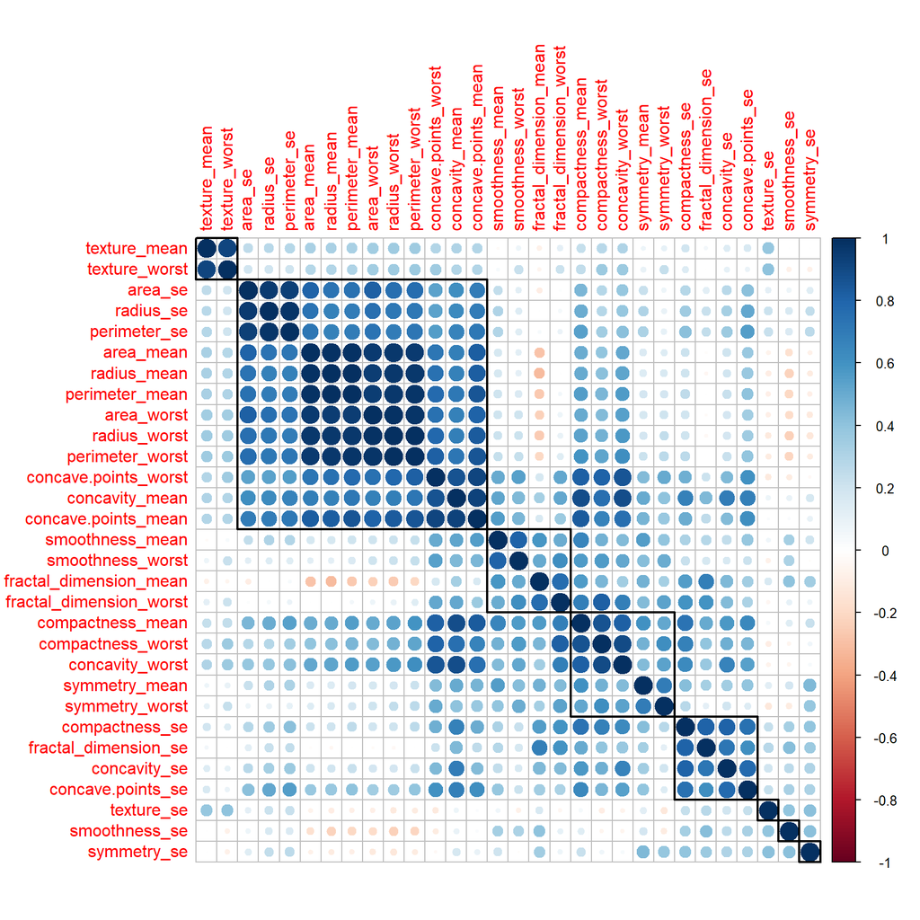

```r
df_corr <- cor(df %>% select(-id, -diagnosis))
corrplot::corrplot(df_corr, order = "hclust", tl.cex = 1, addrect = 8)
```

실제로 상관관계가 있는 변수가 꽤 많습니다. 다음 단계에서는 `caret` 패키지를 사용하여 상관 관계가 높은 항목을 제거합니다.

### Step 4 : Transform the data

```r
library(caret)
# The findcorrelation() function from caret package 상관관계가 높은 예측변수를 제거
# 상관관계가 0.9 이상인 경우를 기준으로 합니다. 이 함수는 휴리스틱 알고리즘을 사용
# 맹목적으로 선택하는 대신 제거해야 할 변수를 결정
df2 <- df %>% select(-findCorrelation(df_corr, cutoff = 0.9))

# 원래 데이터 프레임의 열 수
ncol(df)
```

```
## [1] 32
```

```r
# 새로운 데이터 프레임의 열 수
ncol(df2)
```

```
## [1] 22
```

따라서 새로운 데이터 프레임 `df2`는 10 변수가 더 짧습니다.

### Step 5 : Pre-process the data

#### Using PCA

먼저 PCA 분석을 통해 비지도 분석을 진행해 보겠습니다. 이를 위해 `id` 및 `diagnosis` 변수를 제거한 다음 변수의 크기를 조정하고 중앙에 배치합니다.

```r
# 주성분 분석 수행: 'id'와 'diagnosis' 열을 제외한 나머지 열에 대해 표준화 및 중심 조정
preproc_pca_df <- prcomp(df %>% select(-id, -diagnosis), scale = TRUE, center = TRUE)

# 주성분 분석 결과 요약
summary(preproc_pca_df)
```

```
## Importance of components:
##                           PC1    PC2     PC3     PC4     PC5     PC6     PC7
## Standard deviation     3.6444 2.3857 1.67867 1.40735 1.28403 1.09880 0.82172
## Proportion of Variance 0.4427 0.1897 0.09393 0.06602 0.05496 0.04025 0.02251
## Cumulative Proportion  0.4427 0.6324 0.72636 0.79239 0.84734 0.88759 0.91010
##                            PC8    PC9    PC10   PC11    PC12    PC13    PC14
## Standard deviation     0.69037 0.6457 0.59219 0.5421 0.51104 0.49128 0.39624
## Proportion of Variance 0.01589 0.0139 0.01169 0.0098 0.00871 0.00805 0.00523
## Cumulative Proportion  0.92598 0.9399 0.95157 0.9614 0.97007 0.97812 0.98335
##                           PC15    PC16    PC17    PC18    PC19    PC20   PC21
## Standard deviation     0.30681 0.28260 0.24372 0.22939 0.22244 0.17652 0.1731
## Proportion of Variance 0.00314 0.00266 0.00198 0.00175 0.00165 0.00104 0.0010
## Cumulative Proportion  0.98649 0.98915 0.99113 0.99288 0.99453 0.99557 0.9966
##                           PC22    PC23   PC24    PC25    PC26    PC27    PC28
## Standard deviation     0.16565 0.15602 0.1344 0.12442 0.09043 0.08307 0.03987
## Proportion of Variance 0.00091 0.00081 0.0006 0.00052 0.00027 0.00023 0.00005
## Cumulative Proportion  0.99749 0.99830 0.9989 0.99942 0.99969 0.99992 0.99997
##                           PC29    PC30
## Standard deviation     0.02736 0.01153
## Proportion of Variance 0.00002 0.00000
## Cumulative Proportion  1.00000 1.00000
```

#### 결과 설명:

- Importance of components: 각 주성분의 중요도
- Standard deviation: 주성분의 표준 편차
- Proportion of Variance: 설명된 분산의 비율
- Cumulative Proportion: 누적 설명된 분산의 비율

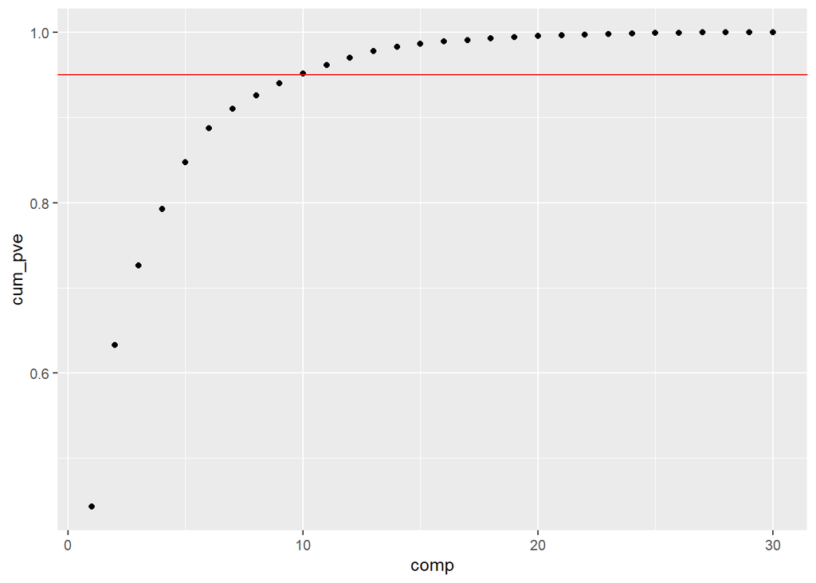

```r
# 각 주성분의 분산 계산
pca_df_var <- preproc_pca_df$sdev^2

# 설명된 분산의 비율 계산
pve_df <- pca_df_var / sum(pca_df_var)

# 누적 설명된 분산 계산
cum_pve <- cumsum(pve_df)

# 주성분, 설명된 분산 비율, 누적 설명된 분산을 데이터프레임으로 정리
pve_table <- tibble(comp = seq(1:ncol(df %>% select(-id, -diagnosis))), pve_df, cum_pve)

# 설명된 분산의 누적 분포를 시각화
ggplot(pve_table, aes(x = comp, y = cum_pve)) +
  geom_point() +
  geom_abline(intercept = 0.95, color = "red", slope = 0)
```

#### 시각화 설명:

원본 데이터 세트를 사용하면 분산의 95%가 10개의 PC로 설명됩니다.

상관관계가 높은 예측 변수를 제거한 두 번째 df에 대해 동일한 작업을 수행해 보겠습니다.

```r
preproc_pca_df2 <- prcomp(df2, scale = TRUE, center = TRUE)
summary(preproc_pca_df2)
```

```
## Importance of components:
##                           PC1    PC2     PC3     PC4     PC5     PC6     PC7
## Standard deviation     3.2051 2.1175 1.46634 1.09037 0.95215 0.90087 0.77121
## Proportion of Variance 0.4669 0.2038 0.09773 0.05404 0.04121 0.03689 0.02703
## Cumulative Proportion  0.4669 0.6707 0.76847 0.82251 0.86372 0.90061 0.92764
##                            PC8    PC9    PC10    PC11    PC12    PC13    PC14
## Standard deviation     0.56374 0.5530 0.51130 0.45605 0.36602 0.31602 0.28856
## Proportion of Variance 0.01445 0.0139 0.01188 0.00945 0.00609 0.00454 0.00378
## Cumulative Proportion  0.94209 0.9560 0.96787 0.97732 0.98341 0.98795 0.99174
##                          PC15   PC16    PC17   PC18   PC19    PC20    PC21
## Standard deviation     0.2152 0.2098 0.16346 0.1558 0.1486 0.09768 0.08667
## Proportion of Variance 0.0021 0.0020 0.00121 0.0011 0.0010 0.00043 0.00034
## Cumulative Proportion  0.9938 0.9958 0.99706 0.9982 0.9992 0.99960 0.99994
##                           PC22
## Standard deviation     0.03692
## Proportion of Variance 0.00006
## Cumulative Proportion  1.00000
```

```r
pca_df2_var <- preproc_pca_df2$sdev^2
```

#### 결과 설명:

- Importance of components: 각 주성분의 중요도
- Standard deviation: 주성분의 표준 편차
- Proportion of Variance: 설명된 분산의 비율
- Cumulative Proportion: 누적 설명된 분산의 비율

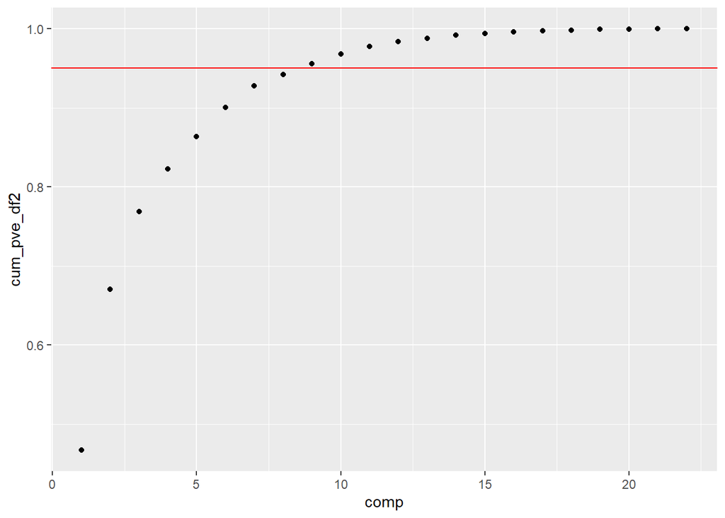

```r
# proportion of variance explained
pve_df2 <- pca_df2_var / sum(pca_df2_var)
cum_pve_df2 <- cumsum(pve_df2)
pve_table_df2 <- tibble(comp = seq(1:ncol(df2)), pve_df2, cum_pve_df2)

ggplot(pve_table_df2, aes(x = comp, y = cum_pve_df2)) +
  geom_point() +
  geom_abline(intercept = 0.95, color = "red", slope = 0)
```

#### 시각화 설명:

처음 2개 구성요소에 대해 가장 큰 영향을 미치는 변수를 시각화

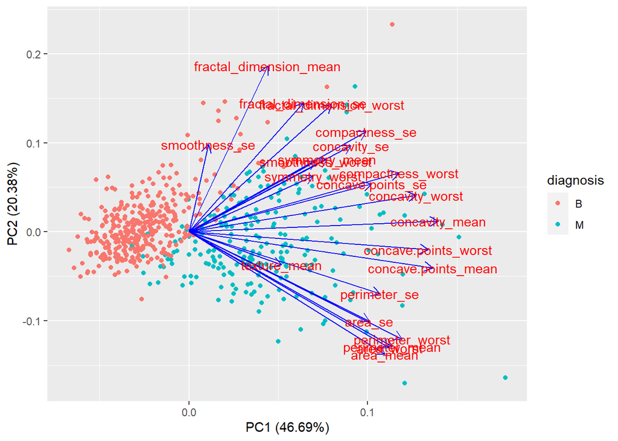

```r
library(ggfortify)
autoplot(preproc_pca_df2, data = df,  colour = 'diagnosis',
                    loadings = FALSE, loadings.label = TRUE, loadings.colour = "blue")
```

처음 3개의 구성 요소를 시각화

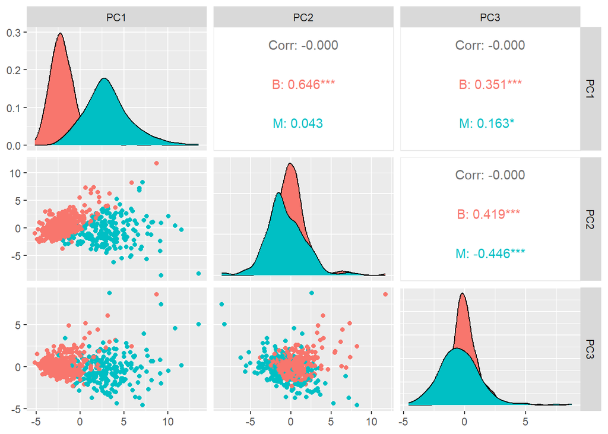

```r
# 주성분 분석 결과를 데이터프레임에 추가 (주성분과 진단 정보)
df_pcs <- cbind(as_tibble(df$diagnosis), as_tibble(preproc_pca_df2$x))

# GGally 패키지의 ggpairs 함수를 사용하여 산점도 행렬 시각화
GGally::ggpairs(df_pcs, columns = 2:4, ggplot2::aes(color = value))
```

### Step 6 : Using LDA

LDA를 사용하면 다양한 클래스를 고려한다는 장점이 있습니다.

```r
preproc_lda_df <- MASS::lda(diagnosis ~., data = df, center = TRUE, scale = TRUE)
preproc_lda_df
```

```
## Call:
## lda(diagnosis ~ ., data = df, center = TRUE, scale = TRUE)
##
## Prior probabilities of groups:
##         B         M
## 0.6274165 0.3725835
##
## Group means:
##         id radius_mean texture_mean perimeter_mean area_mean smoothness_mean
## B 26543825    12.14652     17.91476       78.07541  462.7902      0.09247765
## M 36818050    17.46283     21.60491      115.36538  978.3764      0.10289849
##   compactness_mean concavity_mean concave.points_mean symmetry_mean
## B       0.08008462     0.04605762          0.02571741      0.174186
## M       0.14518778     0.16077472          0.08799000      0.192909
##   fractal_dimension_mean radius_se texture_se perimeter_se  area_se
## B             0.06286739 0.2840824   1.220380     2.000321 21.13515
## M             0.06268009 0.6090825   1.210915     4.323929 72.67241
##   smoothness_se compactness_se concavity_se concave.points_se symmetry_se
## B   0.007195902     0.02143825   0.02599674       0.009857653  0.02058381
## M   0.006780094     0.03228117   0.04182401       0.015060472  0.02047240
##   fractal_dimension_se radius_worst texture_worst perimeter_worst area_worst
## B          0.003636051     13.37980      23.51507        87.00594   558.8994
## M          0.004062406     21.13481      29.31821       141.37033  1422.2863
##   smoothness_worst compactness_worst concavity_worst concave.points_worst
## B        0.1249595         0.1826725       0.1662377           0.07444434
## M        0.1448452         0.3748241       0.4506056           0.18223731
##   symmetry_worst fractal_dimension_worst
## B      0.2702459              0.07944207
## M      0.3234679              0.09152995
##
## Coefficients of linear discriminants:
##                                   LD1
## id                      -2.512117e-10
## radius_mean             -1.080876e+00
## texture_mean             2.338408e-02
## perimeter_mean           1.172707e-01
## area_mean                1.595690e-03
## smoothness_mean          5.251575e-01
## compactness_mean        -2.094197e+01
## concavity_mean           6.955923e+00
```

[output cut: 8 more lines]

```
## compactness_se           1.387026e-01
## concavity_se            -1.768261e+01
## concave.points_se        5.350520e+01
## symmetry_se              8.143611e+00
## fractal_dimension_se    -3.431356e+01
## radius_worst             9.677207e-01
## texture_worst            3.540591e-02
## perimeter_worst         -1.204507e-02
## area_worst              -5.012127e-03
## smoothness_worst         2.612258e+00
## compactness_worst        3.636892e-01
## concavity_worst          1.880699e+00
## concave.points_worst     2.218189e+00
## symmetry_worst           2.783102e+00
## fractal_dimension_worst  2.117830e+01
```

```r
# 시각화 목적으로 LDA에서 df를 만듭니다.
predict_lda_df <- predict(preproc_lda_df, df)$x %>%
  as_tibble() %>%  # as_data_frame()를 as_tibble()로 변경
  cbind(diagnosis = df$diagnosis)
```

### Step 7 : Model the data(데이터 모델링)

먼저 `caret`을 사용하여 테스트 및 훈련 세트를 만들어 보겠습니다.

```r
set.seed(1815)

# 데이터셋 생성 및 분할
df3 <- cbind(diagnosis = df$diagnosis, df2)
df_sampling_index <- createDataPartition(df3$diagnosis, times = 1, p = 0.8, list = FALSE)
df_training <- df3[df_sampling_index, ]
df_testing <-  df3[-df_sampling_index, ]

# 교차 검증을 위한 제어 매개변수 설정
df_control <- trainControl(
  method = "cv",
  number = 15,
  classProbs = TRUE,
  summaryFunction = twoClassSummary
)
```

### Logistic regression

```r
# glm 모델 학습
model_logreg_df <- train(
  diagnosis ~ .,
  data = df_training,
  method = "glm",
  metric = "ROC",
  preProcess = c("scale", "center"),
  trControl = df_control
)

# glm 모델 예측 및 혼동 행렬 생성
prediction_logreg_df <- predict(model_logreg_df, df_testing)
cm_logreg_df <- confusionMatrix(prediction_logreg_df, df_testing$diagnosis, positive = "M")
cm_logreg_df
```

```
## Confusion Matrix and Statistics
##
##           Reference
## Prediction  B  M
##          B 67  0
##          M  4 42
##
##                Accuracy : 0.9646
##                  95% CI : (0.9118, 0.9903)
##     No Information Rate : 0.6283
##     P-Value [Acc > NIR] : <2e-16
##
##                   Kappa : 0.9257
##
##  Mcnemar's Test P-Value : 0.1336
##
##             Sensitivity : 1.0000
##             Specificity : 0.9437
##          Pos Pred Value : 0.9130
##          Neg Pred Value : 1.0000
##              Prevalence : 0.3717
##          Detection Rate : 0.3717
##    Detection Prevalence : 0.4071
##       Balanced Accuracy : 0.9718
##
##        'Positive' Class : M
##
```

`glmnet` 패키지를 사용합니다. `glmnet`은 여러 선형 알고리즘을 통합하므로 항상 고려해야 합니다.

```r
# glmnet 모델 학습
model_glmnet_df <- train(
  diagnosis ~ .,
  data = df_training,
  method = "glmnet",
  metric = "ROC",
  preProcess = c("scale", "center"),
  tuneLength = 20,
  trControl = df_control
)

# glmnet 모델 예측 및 혼동 행렬 생성
prediction_glmnet_df <- predict(model_glmnet_df, df_testing)
cm_glmnet_df <- confusionMatrix(prediction_glmnet_df, df_testing$diagnosis, positive = "M")
cm_glmnet_df
```

```
## Confusion Matrix and Statistics
##
##           Reference
## Prediction  B  M
##          B 71  1
##          M  0 41
##
##                Accuracy : 0.9912
##                  95% CI : (0.9517, 0.9998)
##     No Information Rate : 0.6283
##     P-Value [Acc > NIR] : <2e-16
##
##                   Kappa : 0.981
##
##  Mcnemar's Test P-Value : 1
##
##             Sensitivity : 0.9762
##             Specificity : 1.0000
##          Pos Pred Value : 1.0000
##          Neg Pred Value : 0.9861
##              Prevalence : 0.3717
##          Detection Rate : 0.3628
##    Detection Prevalence : 0.3628
##       Balanced Accuracy : 0.9881
##
##        'Positive' Class : M
##
```

caret 패키지의 varImp 함수를 사용하여 glmnet 모델의 변수 중요도를 계산

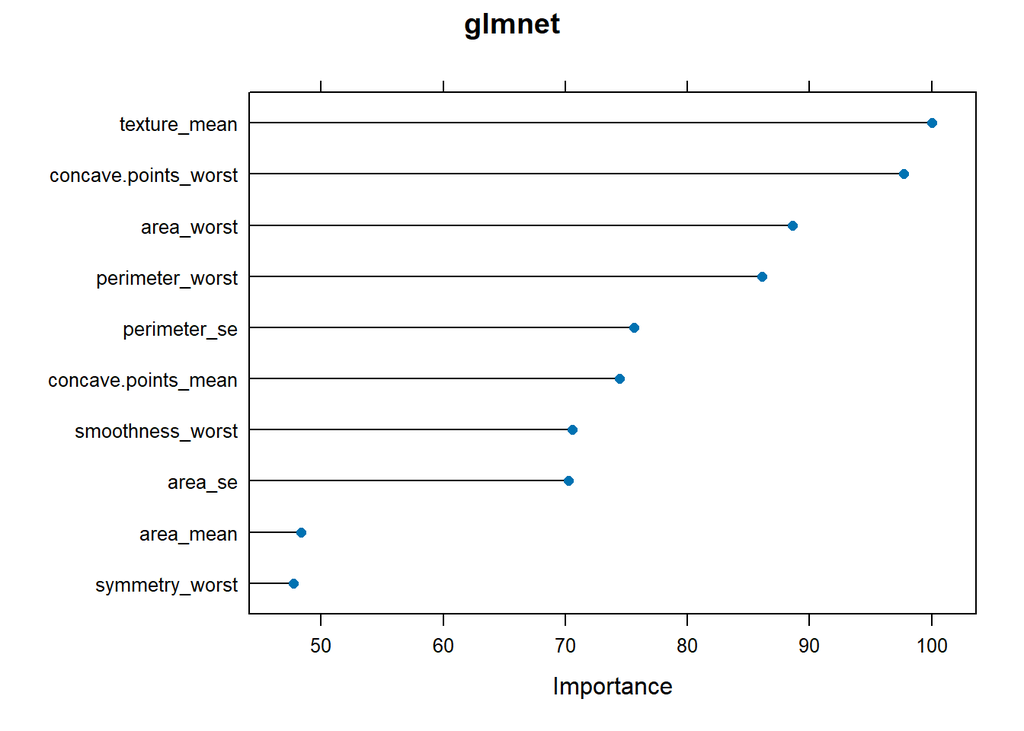

```r
plot(varImp(model_glmnet_df), top = 10, main = "glmnet")
```

결과 그래프는 glmnet 모델에서 상위 10개 변수의 중요도를 보여줍니다. 중요도는 변수가 모델의 예측에 얼마나 기여하는지를 나타냅니다. 그래프를 통해 각 변수의 상대적인 중요도 및 그 중에서 가장 중요한 변수들을 확인할 수 있습니다.

### Random Forest

```r
model_rf_df <- train(diagnosis ~., data = df_training,
                     method = "rf",
                     metric = 'ROC',
                     trControl = df_control)

prediction_rf_df <- predict(model_rf_df, df_testing)
cm_rf_df <- confusionMatrix(prediction_rf_df, df_testing$diagnosis, positive = "M")
cm_rf_df
```

```
## Confusion Matrix and Statistics
##
##           Reference
## Prediction  B  M
##          B 70  1
##          M  1 41
##
##                Accuracy : 0.9823
##                  95% CI : (0.9375, 0.9978)
##     No Information Rate : 0.6283
##     P-Value [Acc > NIR] : <2e-16
##
##                   Kappa : 0.9621
##
##  Mcnemar's Test P-Value : 1
##
##             Sensitivity : 0.9762
##             Specificity : 0.9859
##          Pos Pred Value : 0.9762
##          Neg Pred Value : 0.9859
##              Prevalence : 0.3717
##          Detection Rate : 0.3628
##    Detection Prevalence : 0.3717
##       Balanced Accuracy : 0.9811
##
##        'Positive' Class : M
##
```

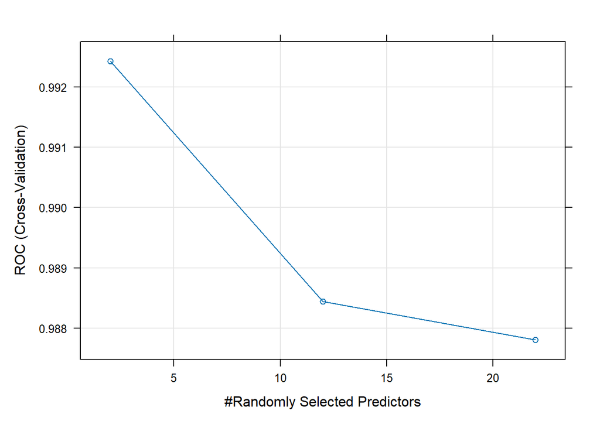

```r
library(randomForest)

plot(model_rf_df)
```

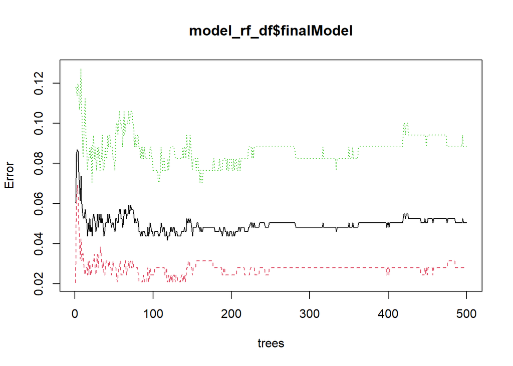

```r
plot(model_rf_df$finalModel)
```

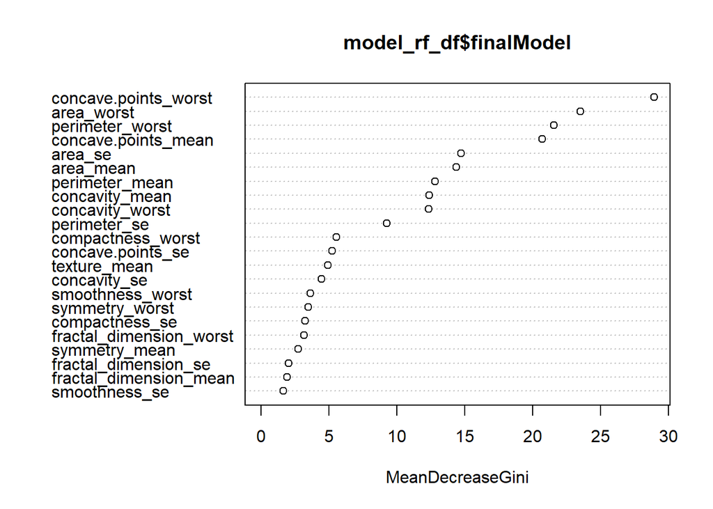

```r
varImpPlot(model_rf_df$finalModel)
```

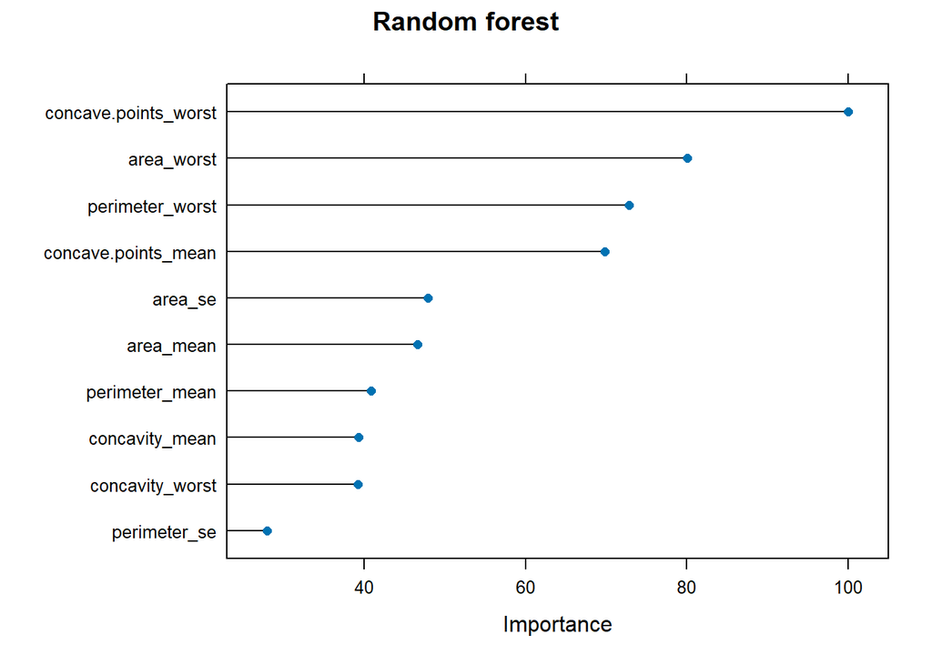

```r
plot(varImp(model_rf_df), top = 10, main = "Random forest")
```

### KNN

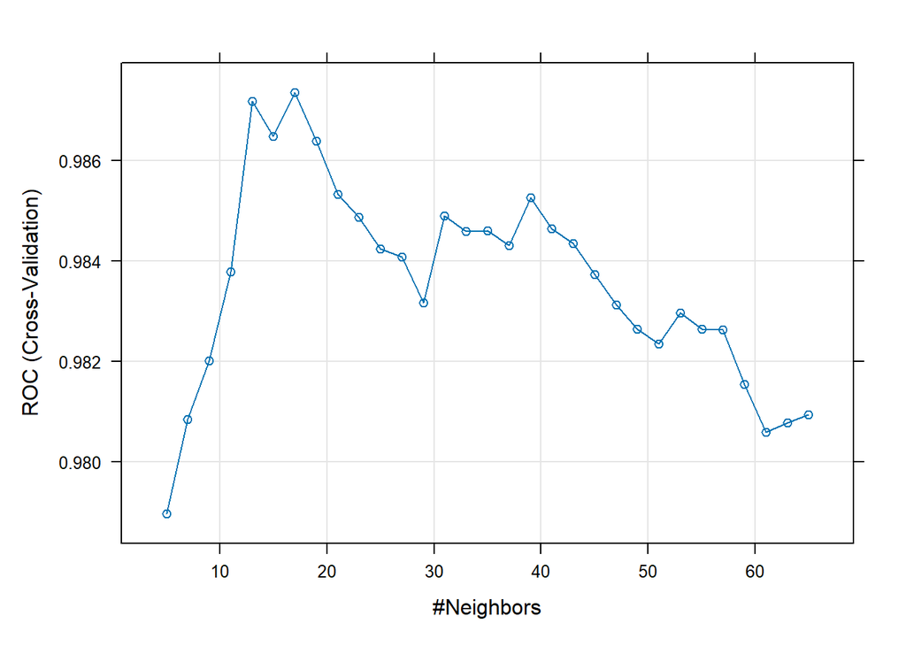

```r
model_knn_df <- train(diagnosis ~., data = df_training,
                      method = "knn",
                      metric = "ROC",
                      preProcess = c("scale", "center"),
                      trControl = df_control,
                      tuneLength =31)

plot(model_knn_df)
```

```r
prediction_knn_df <- predict(model_knn_df, df_testing)
cm_knn_df <- confusionMatrix(prediction_knn_df, df_testing$diagnosis, positive = "M")
cm_knn_df
```

```
## Confusion Matrix and Statistics
##
##           Reference
## Prediction  B  M
##          B 71  3
##          M  0 39
##
##                Accuracy : 0.9735
##                  95% CI : (0.9244, 0.9945)
##     No Information Rate : 0.6283
##     P-Value [Acc > NIR] : <2e-16
##
##                   Kappa : 0.9423
##
##  Mcnemar's Test P-Value : 0.2482
##
##             Sensitivity : 0.9286
##             Specificity : 1.0000
##          Pos Pred Value : 1.0000
##          Neg Pred Value : 0.9595
##              Prevalence : 0.3717
##          Detection Rate : 0.3451
##    Detection Prevalence : 0.3451
##       Balanced Accuracy : 0.9643
##
##        'Positive' Class : M
##
```

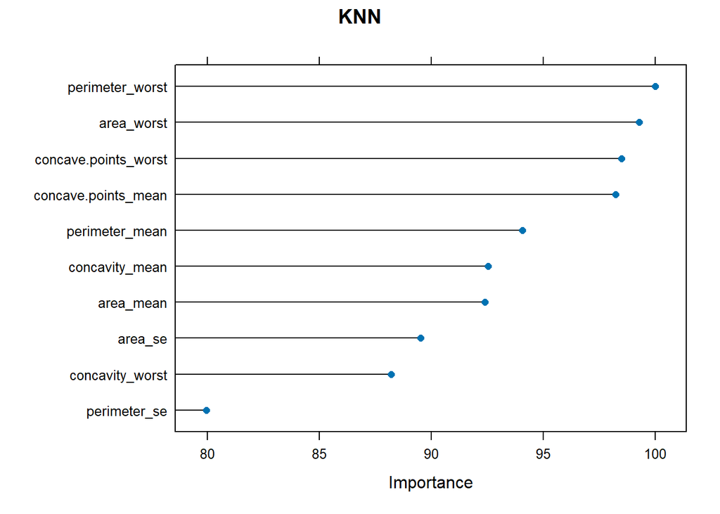

```r
plot(varImp(model_knn_df), top = 10, main = "KNN")
```

### Support Vector Machine(SVM)

```r
model_svm_df <- train(diagnosis ~., data = df_training, method = "svmRadial",
                      metric = "ROC",
                      preProcess = c("scale", "center"),
                      trace = FALSE,
                      trControl = df_control)

prediction_svm_df <- predict(model_svm_df, df_testing)
cm_svm_df <- confusionMatrix(prediction_svm_df, df_testing$diagnosis, positive = "M")
cm_svm_df
```

```
## Confusion Matrix and Statistics
##
##           Reference
## Prediction  B  M
##          B 69  2
##          M  2 40
##
##                Accuracy : 0.9646
##                  95% CI : (0.9118, 0.9903)
##     No Information Rate : 0.6283
##     P-Value [Acc > NIR] : <2e-16
##
##                   Kappa : 0.9242
##
##  Mcnemar's Test P-Value : 1
##
##             Sensitivity : 0.9524
##             Specificity : 0.9718
##          Pos Pred Value : 0.9524
##          Neg Pred Value : 0.9718
##              Prevalence : 0.3717
##          Detection Rate : 0.3540
##    Detection Prevalence : 0.3717
##       Balanced Accuracy : 0.9621
##
##        'Positive' Class : M
##
```

### Neural Network with LDA

- Linear Discriminant Analysis (LDA)를 사용하여 특성을 변환하고, 이를 입력으로 사용하는 Neural Network 모델 LDA 사전 처리 단계를 사용하려면 동일한 훈련 및 테스트 세트도 만들어야 합니다.

```r
# LDA 변환을 위한 학습 데이터 생성
lda_training <- predict_lda_df[df_sampling_index, ]
# LDA 변환을 위한 테스트 데이터 생성
lda_testing <- predict_lda_df[-df_sampling_index, ]

# Neural Network 모델 학습 설정
model_nnetlda_df <- train(
  diagnosis ~ .,                  # 예측 변수 및 설명 변수 설정
  lda_training,                   # 학습 데이터
  method = "nnet",                # Neural Network 모델 선택
  metric = "ROC",                 # 평가 지표 설정
  preProcess = c("center", "scale"),  # 데이터 전처리 설정 (중앙화 및 표준화)
  tuneLength = 10,                # 튜닝을 위한 반복 횟수
  trace = FALSE,                  # 학습 중 메세지 표시 여부
  trControl = df_control          # 교차 검증 및 설정
)

# 테스트 데이터에 대한 Neural Network 모델 예측
prediction_nnetlda_df <- predict(model_nnetlda_df, lda_testing)
# Confusion Matrix 생성
cm_nnetlda_df <- confusionMatrix(
  prediction_nnetlda_df,          # 예측 결과
  lda_testing$diagnosis,          # 실제 클래스
  positive = "M"                  # 양성 클래스 설정
)

# 결과 출력
cm_nnetlda_df
```

```
## Confusion Matrix and Statistics
##
##           Reference
## Prediction  B  M
##          B 70  1
##          M  1 41
##
##                Accuracy : 0.9823
##                  95% CI : (0.9375, 0.9978)
##     No Information Rate : 0.6283
##     P-Value [Acc > NIR] : <2e-16
##
##                   Kappa : 0.9621
##
##  Mcnemar's Test P-Value : 1
##
##             Sensitivity : 0.9762
##             Specificity : 0.9859
##          Pos Pred Value : 0.9762
##          Neg Pred Value : 0.9859
##              Prevalence : 0.3717
##          Detection Rate : 0.3628
##    Detection Prevalence : 0.3717
##       Balanced Accuracy : 0.9811
##
##        'Positive' Class : M
##
```

### Step 8 : Models evaluation

```r
# 다양한 모델의 리스트 생성
model_list <- list(
  logisic = model_logreg_df,         # 로지스틱 회귀 모델
  glmnet = model_glmnet_df,          # glmnet 모델
  rf = model_rf_df,                  # Random Forest 모델
  svm = model_svm_df,                # SVM 모델
  Neural_with_LDA = model_nnetlda_df # LDA와 Neural Network를 결합한 모델
)

# 모델들에 대한 교차 검증 수행 및 결과 저장
results <- resamples(model_list)
```

```r
# 결과 요약
summary(results)
```

```
##
## Call:
## summary.resamples(object = results)
##
## Models: logisic, glmnet, rf, svm, Neural_with_LDA
## Number of resamples: 15
##
## ROC
##                      Min.   1st Qu.    Median      Mean 3rd Qu. Max. NA's
## logisic         0.8793860 0.9766746 0.9952153 0.9769431       1    1    0
## glmnet          0.9425837 0.9820574 1.0000000 0.9896332       1    1    0
## rf              0.9473684 0.9910686 0.9952153 0.9924296       1    1    0
## svm             0.9210526 0.9976077 1.0000000 0.9931419       1    1    0
## Neural_with_LDA 0.9727273 0.9978070 1.0000000 0.9958426       1    1    0
##
## Sens
##                      Min.   1st Qu.    Median      Mean 3rd Qu. Max. NA's
## logisic         0.8421053 0.9473684 0.9473684 0.9580702       1    1    0
## glmnet          0.9473684 1.0000000 1.0000000 0.9964912       1    1    0
## rf              0.8421053 0.9473684 1.0000000 0.9684211       1    1    0
## svm             0.9473684 0.9473684 1.0000000 0.9791228       1    1    0
## Neural_with_LDA 0.9473684 1.0000000 1.0000000 0.9894737       1    1    0
##
## Spec
##                      Min.   1st Qu.    Median      Mean   3rd Qu. Max. NA's
## logisic         0.8181818 0.9090909 0.9166667 0.9414141 1.0000000    1    0
## glmnet          0.8181818 0.9090909 0.9166667 0.9469697 1.0000000    1    0
## rf              0.7272727 0.9090909 0.9090909 0.9101010 0.9583333    1    0
## svm             0.6666667 1.0000000 1.0000000 0.9656566 1.0000000    1    0
## Neural_with_LDA 0.8181818 0.9128788 1.0000000 0.9585859 1.0000000    1    0
```

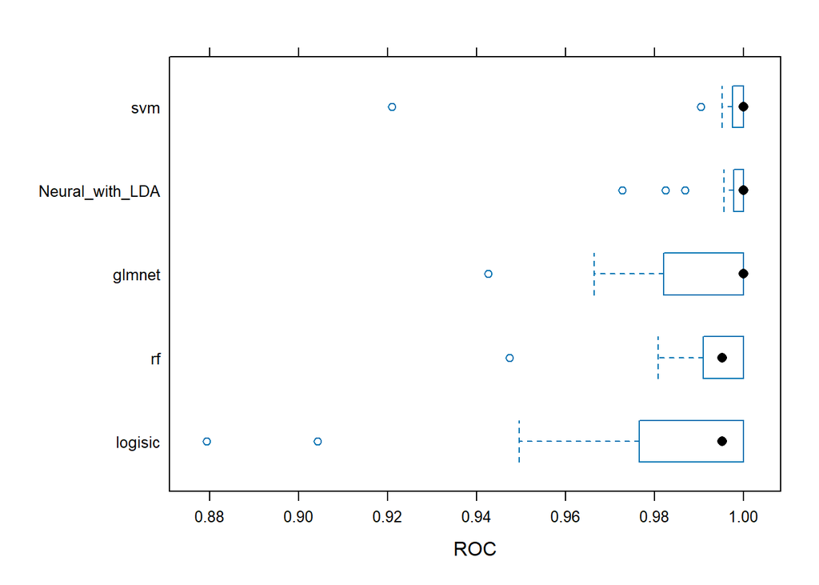

```r
# 각 모델의 ROC 곡선에 대한 비교를 Box-and-Whisker 플롯으로 시각화
bwplot(results, metric = "ROC")
```

* bwplot(results, metric = “ROC”): 각 모델의 ROC 곡선에 대한 비교를 Box-and-Whisker 플롯으로 나타냅니다. 이를 통해 모델 간 성능 차이를 시각적으로 확인할 수 있습니다.

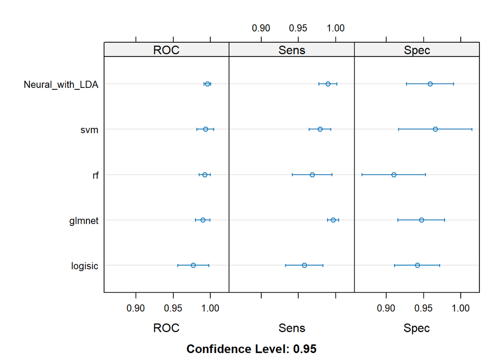

```r
# 각 모델의 ROC 곡선에 대한 비교를 Dot 플롯으로 시각화
dotplot(results)
```

* dotplot(results): 각 모델의 ROC 곡선에 대한 비교를 Dot 플롯으로 나타냅니다. 각 모델의 성능을 더 자세히 비교할 수 있습니다.

#### 결과 해석 마무리

예측 클래스는 기본적으로 임계값 0.5로 얻어지는데, 이는 이와 같은 불균형 데이터 세트에서는 최고가 될 수 없습니다.

```r
cm_list <- list(cm_rf = cm_rf_df, cm_svm = cm_svm_df,
                cm_logisic = cm_logreg_df, cm_nnet_LDA = cm_nnetlda_df)

results <- map_df(cm_list, function(x) x$byClass) %>% as_tibble() %>%
  mutate(stat = "Overall")

results
```

```
## # A tibble: 4 × 12
##   Sensitivity Specificity `Pos Pred Value` `Neg Pred Value` Precision Recall
##         <dbl>       <dbl>            <dbl>            <dbl>     <dbl>  <dbl>
## 1       0.976       0.986            0.976            0.986     0.976  0.976
## 2       0.952       0.972            0.952            0.972     0.952  0.952
## 3       1           0.944            0.913            1         0.913  1
## 4       0.976       0.986            0.976            0.986     0.976  0.976
## # ℹ 6 more variables: F1 <dbl>, Prevalence <dbl>, `Detection Rate` <dbl>,
## #   `Detection Prevalence` <dbl>, `Balanced Accuracy` <dbl>, stat <chr>
```

결론적으로 우리는 아래 3가지를 Breast_Cancer 데이터에 대해서 great models라고 할수 있다.

1. random forest
2. LDA with neural net
3. glmnet

## References

A useful popular kernel on this dataset on [Kaggle](https://www.kaggle.com/lbronchal/breast-cancer-dataset-analysis) Another one, also on [Kaggle](https://www.kaggle.com/sonicboom8/breast-cancer-data-with-logistic-randomforest) And [another one](https://www.kaggle.com/murnix/cluster-rf-boosting-svm-accuracy-97-auc-0-96/notebook), especially nice to compare models.